# ISYE 6420: Homework 3

aelhabr3

# 1. Estimating the Precision Parameter of a Rayleigh Distribution.

## Instructions

If two random variables $X$ and $Y$ are independent of each other and normally distributed with variances equal to $\sigma^2$, then the variable $R = \sqrt{X^2+Y^2}$ follows the Rayleigh distribution. Parameterized with precision parameter $\xi = \frac{1}{\sigma^2}$, the Rayleigh random variable $R$ has a density

$$\begin{array}{c}
f(r) = \xi r \text{ exp } \{ \frac{-\xi r^2}{2} \}, \quad r \geq 0, \xi > 0.
\end{array}$$

An example of such random variable would be the distance of darts from the target center in a dart-throwing game where the deviations in the two dimensions of the target plane are independent and normally distributed.  
(a) Assume that the prior on $\xi$ is exponential with the rate parameter $\lambda$. Show that the posterior is gamma $\mathcal{Ga}(2, \lambda+\frac{r^2}{2})$.  
(b) Assume that $R_1 = 3, R_2 = 4, R_3 = 2$, and $R_4 = 5$ are Rayleigh-distributed random observations representing the distance of a dart from the center. Find the posterior in this case for the same prior from (a), and give a Bayesian estimate of $\xi$.  
(c) For $\lambda = 1$, Numerically find 95% Credible Set for $\xi$.  
Hint: In (b) show that if $R_1, R_2, \dots, r_n$ are observed, and the prior on $\xi$ is exponential $\mathcal{E}(\lambda)$, the the posterior is gamma $\mathcal{Ga}(n+1, \lambda+\frac{1}{2}\sum_{i=1}^{n} r_i^2)$.

## Response

### a

*As a note to the grader, this proof is very similar to that shown for the third problem in the [solutions for Homework 2 for the Spring 2019 semester](https://www2.isye.gatech.edu/~brani/isye6420/Bank/Homework2solutions.pdf).*

Recall Bayes’ formula (expressed here in the symbols used by the instructions).

$$\begin{array}{c}
\pi\left(\xi | r_{1}, \ldots, r_{n}\right)=\frac{f\left(r_{1}, \ldots, r_{n} | \xi\right) \pi(\xi)}{m\left(r_{1}, \ldots, r_{n}\right)}
\end{array}$$

We will work towards formulating the posterior $\pi\left(\xi | r_{1}, \ldots, r_{n}\right)$ by looking at each of its components—the prior $\pi(\xi)$, the likelihood $f\left(r_{1}, \ldots, r_{n} | \xi\right)$, and the $m\left(r_{1}, \ldots, r_{n}\right)$. We will assume that $f\left(r_{1}, \ldots, r_{n} | \xi\right) = f\left(r_{1}, \ldots, r_{n}\right)$ in what follows.

First, we start with the prior. Given that the prior follows the Exponential distribution distribution $\xi \sim \mathcal{Exp}(\lambda)$, we can express it as $\pi(\xi) = \lambda e^{-\lambda \xi}$.

Next, we look at the likelihood. Since we know that the population is distributed as $f(r) = \xi r e^{-(\xi r^2)/2}$, we can say that the likelihood is

$$\begin{array}{rcl}
f\left(r_{1}, \ldots, r_{n} | \xi\right)
& = & f\left(r_{1}, \ldots, r_{n}\right) \\
& = & \prod_{i=1}^{n} f(r_i) \\
& = & \xi^n \prod_{i=1}^{n} r_i e^{-\frac{1}{2}\xi \sum_{i=1}^n r^2} \\
& \propto & \xi^n e^{-\frac{1}{2}\xi \sum_{i=1}^n r^2}.
\end{array}$$

(Note that we “drop” the term $\prod_{i=1}^{n} r_i$ since it is just a constant.)

Next, we can formulate the marginal as follows.

$$\begin{aligned}
m\left(r_{1}, \ldots, r_{n}\right)
& = \int_{0}^{\infty} f\left(r_{1}, \ldots, r_{n} | \xi\right) \pi(\xi) d \xi \\
& = \int_{0}^{\infty} f\left(r_{1}, \ldots, r_{n}\right) \pi(\xi) d \xi \\
& = \int_{0}^{\infty} \xi^{n} e^{-\sum_{i=1}^{n} r_{i} \xi} \lambda e^{-\lambda \xi} d \xi \\
& = \lambda \int_{0}^{\infty} \xi^{n} e^{-\left(\sum_{i=1}^{n} r_{i}+\lambda\right) \xi} d \xi.
\end{aligned}$$

We will re-express the marginal $m$ shortly. First, recall the properties of the Gamma distribution $\mathcal{Ga}(\alpha, \beta)$ for a random variable $X$ where $\alpha < 0, \beta > 0, x \geq 0$.

$$\begin{aligned}
f(x | \alpha, \beta) &=\frac{\beta^{\alpha}}{\Gamma(\alpha)} x^{\alpha-1} e^{-\beta_{x}} \\
\mathbb{E}[X | \alpha, \beta] &=\frac{\alpha}{\beta} \\ \operatorname{Var}(X | \alpha, \beta) &=\frac{\alpha}{\beta^{2}} \end{aligned}$$

We can re-express the PDF $f$ of the Gamma distribution as $\int_{0}^{\infty} \frac{\beta^{\alpha}}{\Gamma(\alpha)} y^{\alpha-1} e^{-\beta y}=1$ after substituting $\Gamma(\alpha)=\int_{0}^{\infty} u^{\alpha-1} e^{-u} d u$ (in the denominator).

Next, we go back and re-express the marginal $m$ as so.

$$\begin{aligned}
m\left(r_{1}, \ldots, r_{n}\right) &=\frac{\lambda \Gamma(n+1)}{\left(\lambda+\sum_{i=1}^{n} r_{i}\right)^{n+1}} \int_{0}^{\infty} \frac{\left(\lambda+\sum_{i=1}^{n} r_{i}\right)^{n+1}}{\Gamma(n+1)} \xi^{(n+1)-1} e^{-\left(\lambda+\sum_{i=1}^{n} r_{i}\right) \xi} d \xi \\ &=\frac{\lambda \Gamma(n+1)}{\left(\lambda+\sum_{i=1}^{n} r_{i}\right)^{n+1}}
\end{aligned}$$

Finally, we put together our expressions for the prior, the likelihood, and the marginal as follows..

$$\begin{aligned}
\pi\left(\xi | r_{1}, \ldots, r_{n}\right)
&=\frac{\lambda \xi^{n} e^{-\left(\lambda+\frac{1}{2}\sum_{i=1}^{n} r_i\right) \xi}}{\left(\lambda+\sum_{i=1}^{n} r_{i}\right)^{n+1}} \\ &=\frac{\left(\lambda+\sum_{i=1}^{n} r_{i}\right)^{n+1}}{\Gamma(n+1)} \xi^{n} e^{-\left(\lambda+\frac{1}{2}\sum_{i=1}^{n} r_i\right) \xi}
\end{aligned}$$

The above expression is the kernel for the Gamma distribution $\mathcal{Ga}(\alpha,\beta)$ with $\alpha=n+1, \beta=\lambda+\frac{1}{2}\sum_{i=1}^{n} r_i^2$. (This is what is indicated by the hint).

Then, for the case of $n=1$, we see that $\mathcal{Ga}(2, \lambda+\frac{1}{2} r^2)$.

### b

Using the general form of the posterior shown above with $n=4$ and $\sum_{i=1}^{n} r_i^2 = 3^2 + 4^2 + 2^2 + 5^2) = 54$, we find that the posterior is
$$\begin{array}{c}
\mathcal{Ga}((4)+1, \lambda+\frac{1}{2}(54)) = \mathcal{Ga}(5, \lambda + 27).
\end{array}$$

The Bayesian estimate of $\xi$ is simply the expected value of the parameter under the posterior distribution.

We note that if $X \sim \mathcal{Ga}(\alpha, \beta)$, then

$$\begin{array}{c}
\operatorname{E}(X) = \frac{\alpha}{\beta}.
\end{array}$$

Thus, given that $\xi \sim \mathcal{Ga}(5, \lambda + 27)$, we find that the Bayesian estimate $\xi_{Bayes}$ of $\xi$ is

$$\begin{array}{c}
\xi_{Bayes} = \operatorname{E}(\xi) = \frac{5}{\lambda + 27}.
\end{array}$$

### c

The equitailed credible set $C$ is based on the posterior distribution. This means that the set $C = [L, U]$ contains the true parameter $1-\alpha$ probability. Here, the parameter is $\xi$ and $\alpha=0.05$.

Formally, an equitailed credible set is calculated as follows.

$$\begin{array}{c}
\int_{-\infty}^{L} \pi(p|x) dp \leq \frac{\alpha}{2},
\int_{U}^{+\infty} \pi(p|x) dp \leq \frac{\alpha}{2} \\
\text{ s.t. }
\Pr(p \in \left[L, U\right] | X) \geq 1 - \alpha
\end{array}$$

We can calculate the 95% equitailed credible set in `R` (given $\lambda = 1$) as follows.

```r
compute_equi_credible_set <- function(alpha, beta, level = 0.95) {
  q_buffer <- (1 - level) / 2
  q_l <- (1 - level) - q_buffer
  q_u <- level + q_buffer
  res <-
    c(
      l = qgamma(q_l, shape = alpha, rate = beta),
      u = qgamma(q_u, shape = alpha, rate = beta)
    )
}
alpha_1 <- 5
lambda_1 <- 1
beta_1 <- lambda_1 + 27
credible_set_1 <- compute_equi_credible_set(alpha_1, beta_1)
credible_set_1
```

```
##          l          u
## 0.05798166 0.36577102
```

We find that the 95% credible set is [0.0580, 0.3658].

# 2. Estimating Chemotherapy Response Rates

## Instructions

An oncologist believes that 90% of cancer patients will respond to a new chemotherapy treatment and that it is unlikely that this proportion will be below 80%. Elicit a beta prior on proportion that models the oncologist’s beliefs.  
Hint: For elicitation of the prior use $\mu = 0.9, \mu − 2 \sigma = 0.8$ and expressions for $\mu$ and $\sigma$. for beta.  
During the trial, in 30 patients treated, 22 responded.  
(a) What are the likelihood and posterior distributions? What is the Bayes estimator of the proportion?  
(b) Using Octave, R, or Python, fine 95% Credible Set for $p$.  
(c) Using Octave, R, or Python, test the hypothesis $H_0 : p \geq 4/5$ against the alternative $H_1 : p < 4/5$.  
(d) Using WinBUGS, find the Bayes estimator, Credible Set and test, and compare results with (a-c).

(a) likelihood -> 2018s-hw03-q2-a, ~2018s-hw03-q1-a posterior -> 2018f-hw03-q1-iii, ~2018s-hw03-q1-a, ~2018s-hw03-q2-b Bayes -> 2018f-hw03-q1-iii (b) -> 2018f-hw03-q1-iii, 2018s-hw03-q2-c (c) -> ~2018s-hw03-q1-c (d) -> 2018f-hw03-q1-iii, ~2018s-hw03-q1-d, 2018s-hw03-q2-d

## Response

We can verify that values with `R`.

```r
alpha_0 <- 0.72
beta_0 <- 0.18
compute_beta_mu <- function(alpha, beta) {
  alpha / (alpha + beta)
}
mu_0 <- compute_beta_mu(alpha_0, beta_0)
mu_0
```

```
## [1] 0.8
```

### a

Given the problem statement, we deduce the likelihood follows a binomial $\mathcal{Bin}(n, p)$ distribution.

$$\begin{array}{c}
X \sim \mathcal{Bin}(n, p) \\
f(x|p) = \left( \begin{array}{c} n \\ x \end{array} \right) p^{x} (1 - p)^{n-x}
\end{array}$$

And, given $n=30$ patients, $x=22$ of whom responded, the likelihood is

$$\begin{array}{c}
f(x|p) = \left( \begin{array}{c} 30 \\ 22 \end{array} \right) p^{22} (1 - p)^{8}.
\end{array}$$

The posterior distribution $\pi (p | x)$ is proportional to the product of the likelihood $f(x|p)$ and the prior distribution $\pi(p)$.

$$\begin{array}{lcl}
\pi(p | x) & \propto & f(x | p) \pi(p) \\
& \propto & p^{x}(1-p)^{n-x}
\end{array}$$

Next, we note that the general form the Beta distribution is

$$\begin{array}{c}
X \sim \mathcal{Be}(\alpha, \beta) \\
f(x)=\frac{1}{\operatorname{B}(\alpha,\beta)} x^{\alpha - 1} (1-x)^{\beta-1}
\end{array}$$

where $0 \leq x \leq 1, \alpha, \beta > 0$, $\operatorname{B}(\alpha,\beta) = \frac{\Gamma(\alpha) \Gamma(\beta)}{\Gamma(\alpha + \beta)}$ and $\Gamma(\alpha) = \int_{0}^{\infty} t^{\alpha-1} e^{-t} dt$.

We can re-structure the posterior distribution to look like the general Beta distribution.

$$\begin{array}{lcl}
\pi(p | x) & \propto & p^{x}(1-p)^{n-x} \\
& = & p^{(x+1)-1} (1-p)^{(n-x+1)-1}.
\end{array}$$

Then, defining $\alpha ^\prime = x + 1, \beta ^\prime = n - x + 1$, we write the posterior distribution as

$$\begin{array}{lcl}
\pi(p|x) & \sim & \mathcal{Be}(\alpha ^\prime, \beta ^\prime) \\
& \sim & \mathcal{Be}(x + 1, n - x + 1).
\end{array}$$

Finally, given $n=30,x=22$, we find that the posterior distribution

$$\begin{array}{lcl}
\mathcal{Be}(x + 1, n - x +1) & = & \mathcal{Be}(22 + 1, 30 - 22 + 1) \\
& = & \mathcal{Be}(23, 9).
\end{array}$$

The Bayes estimator of the proportion $p_{Bayes}$ is simply the expected value of the parameter under the posterior distribution.

We note that if $X \sim \mathcal{Be}(\alpha, \beta)$, then

$$\begin{array}{c}
\operatorname{E}(X) = \frac{\alpha}{\alpha+\beta}.
\end{array}$$

Thus, we find that

$$\begin{array}{lcl}
p_{Bayes} = \operatorname{E}(X)
& = & \frac{(23)}{(23)+(9)} \\
& = & \frac{23}{32} \\
& = & 0.71875.
\end{array}$$

We can verify the posterior mean $\mu_1$ using `R`.

```r
n <- 30
x <- 22
alpha_1 <- x + 1
beta_1 <- n - x + 1
mu_1 <- compute_beta_mu(alpha_1, beta_1)
mu_1
```

```
## [1] 0.71875
```

### b

We can calculate the 95% credible set using `R` (using the function created in 1(c)).

```r
credible_set_1 <- compute_equi_credible_set(alpha_1, beta_1)
credible_set_1
```

```
##        l        u
## 1.620003 3.700918
```

We find that the 95% credible set is [1.6200, 3.7009].

### c

To test the null hypothesis $H_0 : p \geq 4/5$ against the alternative $H_1 : p < 4/5$, let’s calculate the posterior probability of the alternative first (using `R`).

```r
p_h1 <- 4/5
p_h1 <- pbeta(p_h1, alpha_1, beta_1, lower.tail = TRUE)
p_h1
```

```
## [1] 0.8492375
```

Then we find that the probability of the null hypothesis is

$$\begin{array}{c}
\Pr(H_0 : p \geq 4/5) = 1 - \Pr(H_1 : p < 4/5) = 0.1508.
\end{array}$$

Since we find that the alternative hypothesis $H_1$ has a probability greater than 0.5, we choose to accept the alternative hypothesis over the null hypothesis $H_0$.

Note that Bayesian hypothesis testing is different than Frequentist hypothesis testing. Vidakovic explains in [*Engineering Biostatistics*](http://statbook.gatech.edu/statb4.pdf).

> “In frequentist tests, it was customary to formulate $H_0$ as $H_0 : \theta = 0$ versus $H_1 : \theta > 0$ instead of $H_0 : \theta \leq 0$ versus $H_1 : \theta > 0$, as one might expect. The reason was that we calculated the p-value under the assumption that $H_0$ is true, and this is why a precise null hypothesis was needed.  
> ”Bayesian testing is conceptually straightforward: The hypothesis with a higher posterior probability is favored. There is nothing special about the “null” hypothesis, and for a Bayesian, $H_0$ and $H_1$ are interchangeable."

### d

Below is OpenBUGS code to evaluate each of the results found above.

[figure not shown]

Note the following about the implementation in OpenBUGS.

- Initial values were generated via “gen inits”;
- 1,000 burn-in samples were used;
- 10,000 samples were used for estimation.

The output is shown below.

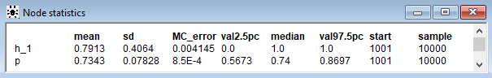

The probability of the alternative hypothesis $H_1$ corresponds to the posterior mean of the `h_1` variable—0.7913. This is relatively close to the value that we found with `R`—0.8492.

### Aside

We can use the `R` package `{R2OpenBUGS}` to achieve the same results found directly in OpenBUGS.

```r
model <- function() {
  x ~ dbin(p, n)
    p ~ dbeta(alpha, beta)
    h_1 <- step(4/5 - p)
}
data <- list(alpha = 0.72, beta = 0.18, x = 22, n = 30)
inits <- NULL
params <- c('h_1', 'p')
res_sim <-
  R2OpenBUGS::bugs(
    data = data,
    inits = inits,
    model.file = model,
    parameters.to.save = params,
    DIC = FALSE,
    n.chains = 1,
    n.iter = 10000,
    n.burnin = 1000
  )
res_sim$summary
```

[output not shown]

|  | mean | sd | 2.5% | 25% | 50% | 75% | 97.5% |
| --- | --- | --- | --- | --- | --- | --- | --- |
| h_1 | 0.7912222 | 0.4064578 | 0.0000000 | 1.0000 | 1.00 | 1.000 | 1.0000 |
| p | 0.7343966 | 0.0781395 | 0.5678975 | 0.6837 | 0.74 | 0.791 | 0.8697 |